# Trabalhando com mapas do Brasil

Elias T. Krainski

Criado em “Outubro, 2018”, Atualizado em 2023-01-30

Neste tutorial, obtemos mapas oficiais do Brasil dividido por municípios, definimos o grafo de vizinhança e simulamos de um modelo espacial. Ao final mostramos como fazer a lista de vizinhança entre todos os municípios do Brasil ligando também municípios sem vizinhos a municípios próximos.

# Mapa

## Fonte de mapas oficiais

No link [http://geoftp.ibge.gov.br/organizacao_do_territorio/malhas_territoriais/] estão disponíveis mapas oficiais da divisão territorial Brasileira desde o ano de 1872. Vamos considerar o mapa do Paraná subdividido por municípios considerando a divisão de 2019.

Inicialmente definimos o link do arquivo com o shapefile compactado e o arquivo local com o objeto em ambiente R.

```r
u0 <- paste0(
  'http://geoftp.ibge.gov.br/',
  'organizacao_do_territorio/',
  'malhas_territoriais/malhas_municipais/')
map.dir <- 'municipio_2019/UFs/PR/'
map.zip <- 'pr_municipios.zip'
map.rds <- "map.rds"
```

## Download e importação

```r
if (!file.exists(map.rds)) {
  library(rgdal)
  if (!file.exists(map.zip)) {
    download.file(paste0(u0, map.dir, map.zip), map.zip)
  }
  if (!file.exists('PR_Municipios_2019.shp'))
    unzip(map.zip)
  saveRDS(readOGR('.', 'PR_Municipios_2019'),
          map.rds)
}
map <- readRDS(map.rds)
```

## Inspeciona e plota

```r
dim(map)
```

```
## [1] 399   4
```

```r
head(map@data, 3)
```

```
##    CD_MUN        NM_MUN SIGLA_UF AREA_KM2
## 0 4100103        Abatiá       PR  228.717
## 1 4100202  Adrianópolis       PR 1349.311
## 2 4100301 Agudos do Sul       PR  192.261
```

Há 399 areas nesse mapa e podemos visualizar esse mapa com

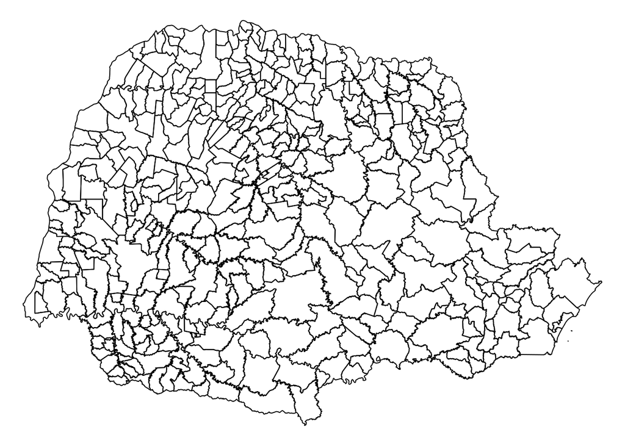

```r
par(mar=c(0,0,0,0))
plot(map)
```

## Um sub-conjunto de municípios

Nós vamos fazer visualizações e para que fique mais didático vamos considerar apenas os municípios com centroide a menos de 70 kilômetros do centroide de Guaratuba. Inicialmente, calculamos a distância (em km) de cada município a Guaratuba:

```r
ig <- which(map@data$NM_MUN=='Guaratuba')
ce <- coordinates(map)
dist.g <- spDistsN1(ce, ce[ig, ], longlat=TRUE)
summary(dist.g)
```

```
##    Min. 1st Qu.  Median    Mean 3rd Qu.    Max.
##     0.0   303.6   403.2   373.3   473.8   580.1
```

Agora, selecionamos aqueles com distância menor que 70 kilometros:

```r
ii <- which(dist.g<70)
mapa <- map[ii, ]
```

# Vizinhança

A lista de vizinhança pode ser obtida usando a função `poly2nb()` do pacote **spdep**, Bivand and Piras (2015).

```r
library(spdep)
viz <- poly2nb(mapa)
viz
```

```
## Neighbour list object:
## Number of regions: 15
## Number of nonzero links: 58
## Percentage nonzero weights: 25.77778
## Average number of links: 3.866667
```

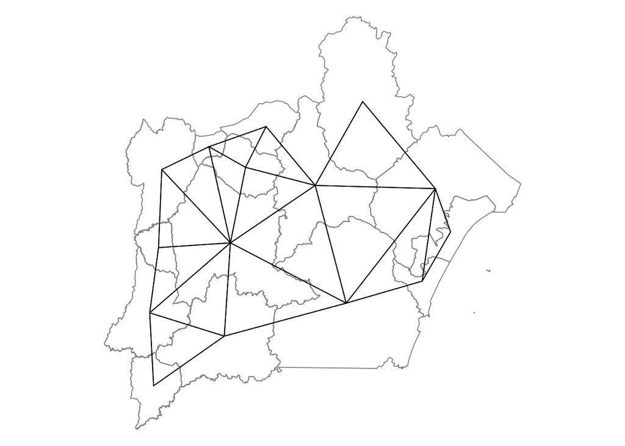

```r
par(mar=c(0,0,0,0))
plot(mapa, border=gray(.5))
ce.mapa <- ce[ii, ]
plot(viz, ce.mapa, add=TRUE, points=FALSE)
text(ce.mapa[,1], ce.mapa[,2], mapa$NM_MUNICIP, cex=0.5, col='blue')
```

# Um exemplo de modelo espacial

## Definição teórica

O modelo de Besag mais simples é definido por distribuições condicionais da forma
$$x_i | \mathbf{x}_{-i}
\sim \textrm{Normal}(m_i, v_i)$$
em que $\mathbf{x}_{-i}$ é o vetor $\mathbf{x}$ sem a posição $i$.

- $m_i = \sum_{j\sim i}x_j/n_i$ em que
  - $j\sim i$ indica o conjunto de áreas vizinhas da área $i$
  - $n_i$ é o número de vizinhos da área $i$
- $v_i = \frac{1}{n_i\tau}$
  - variância condicional é inversamente proporcinal ao número de vizinhos
  - $\tau$ é um parâmetro de precisão condicional/local

Esse conjunto de distribuições condicionais induz uma distribuição conjunta intrinsica para o vetor $\mathbf{x}$:
$$\mathbf{x} \sim \textrm{Normal}(\mathbf{0}, \mathbf{Q}^{-})\;.$$
em que $\mathbf{Q}^{-}$ é a inversa generalizada de $\mathbf{Q}$.

O ingrediente principal desta distribuição é a matriz de precisão dada por
$$\mathbf{Q} = \tau
\mathbf{R}$$
onde

$$R_{ij} = \left\{ \begin{array}{rl}
n_i, & \textrm{ se } i=j \\
-1, & \textrm{ se } i\sim j \\
0, & \textrm{ caso contrario}
\end{array} \right.$$

## Definição em R

Podemos construir $\mathbf{R}$ a partir da matriz de vizinhanças com

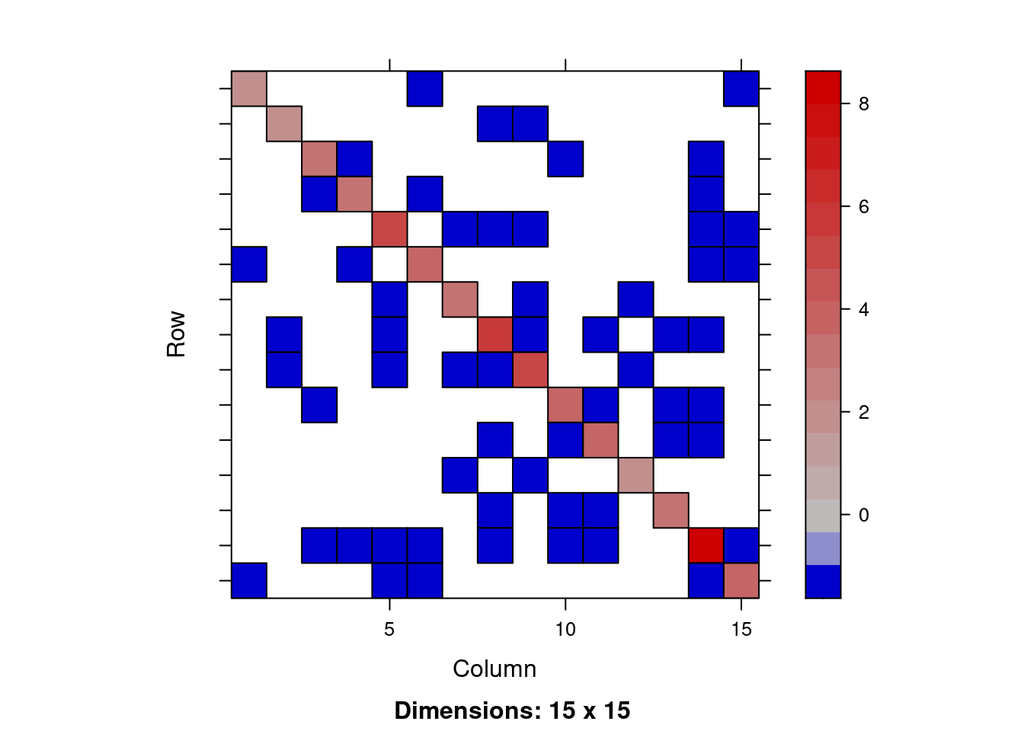

```r
ni <- card(viz)
n <- length(ni)
library(Matrix)
grafo <- sparseMatrix(i=rep(1:n, ni), j=unlist(viz))
R <- Diagonal(x=ni) - grafo
image(R, scales=list(y=list(at=1:nrow(R), label=mapa$NM_MUNICIP)))
```

## Simulando do modelo

Falta ainda definir o valor de $\tau$ de forma a completar a definição do modelo. Recomendamos fortemente escalonar a matriz $\mathbf{R}$ para que em vez de parametrizar $\tau$ usar um parâmetro de variância marginal, conforme sugerido em Sørbye and Rue (2014) para o modelo de Besag e utilizado em Riebler et al. (2016) para uma reparametrização do modelo de Besag-York-Mollié, Besag, York, and Mollié (1991).

Para a simulação, vamos considerar o mapa do estado do Paraná.

```r
viz <- poly2nb(map)
ni <- card(viz)
n <- length(ni)
grafo <- sparseMatrix(i=rep(1:n, ni), j=unlist(viz))
R <- Diagonal(x=ni) - grafo
```

Fazemos isso a seguir, considerando a restrição de soma zero.

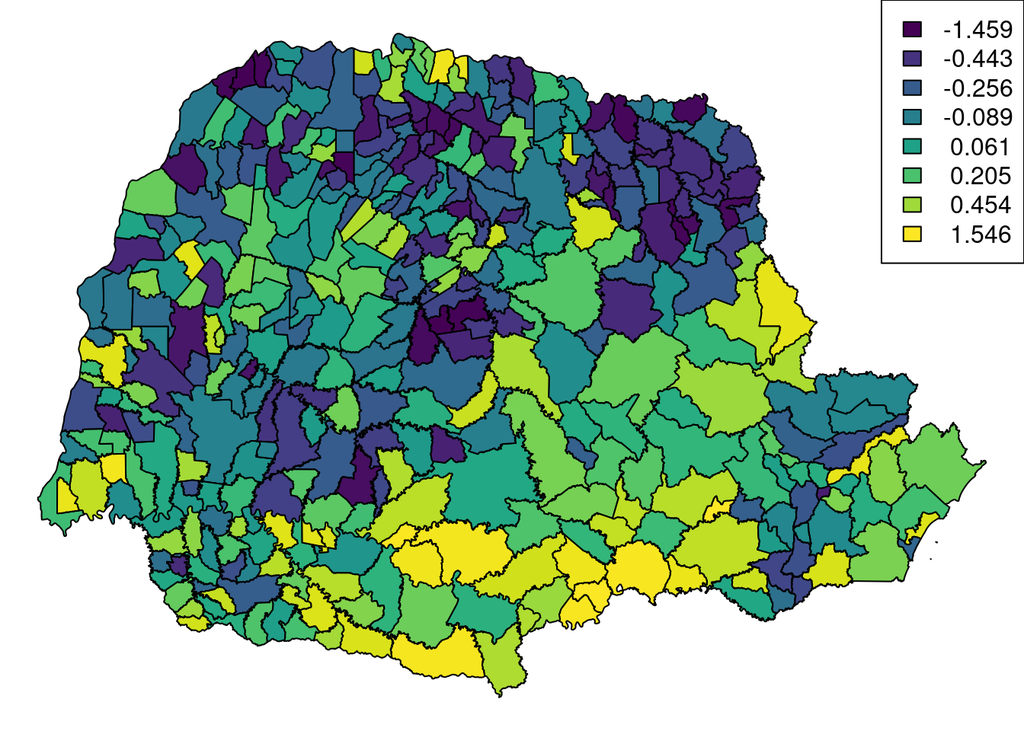

```r
constr0 <- list(A=matrix(1, 1, n), e=0)
library(INLA)
Rscale <- inla.scale.model(R, constr=constr0)
tau.m <- 4
x <- inla.qsample(Q = tau.m * Rscale + Diagonal(n, 1e-5),
                  constr = constr0)

library(viridisLite)
cores <- viridis(n)

par(mar=c(0,0,0,0))
plot(map, col=cores[rank(x)])
q <- quantile(x, 0:7/7)
library(maptools)
legend('topright',
       format(q, digits=2),
       fill=viridis(8))
```

# Vizinhança dos municípios do Brasil

## Obtendo o mapa

Obtemos o mapa e importamos de forma similar ao que fizemos no início.

```r
brdir <- 'municipio_2019/Brasil/BR/'
fl.zip <- 'br_municipios_20200807.zip'
fl.rds <- 'brmun.rds'
if (!file.exists(fl.rds)) {
  if (!file.exists(fl.zip)) {
    download.file(paste0(u0, brdir, fl.zip), fl.zip)
  }
  if (!file.exists('BR_Municipios_2019.shp'))
    unzip(fl.zip)
  saveRDS(readOGR('.', 'BR_Municipios_2019'),
          fl.rds)
}
map <- readRDS(fl.rds)
```

## Lista de vizinhança inicial

Vamos criar uma lista de vizinhança em 2 passos. Criamos uma lista de vizinhança como no exemplo anterior e depois verificamos a existência de municípios sem vizinhos aos quais adicionamos connecções a municípios próximos.

Criamos uma lista inicial de vizinhos. Como esse passo pode demorar alguns minutos, salvamos ela para poder evitar obtê-la novamente mais de uma vez.

```r
if (!file.exists('nb0.rds')) {
  saveRDS(poly2nb(map), "nb0.rds")
}
nb0 <- readRDS("nb0.rds")
```

## Adiciona vizinhos à áreas isoladas

Obtemos o numero de vizinhos de cada área

```r
nn0 <- card(nb0)
n0 <- sum(nn0==0)
n0
```

```
## [1] 2
```

Procuramos municípios próximos aos municípios sem vizinhos

```r
coo <- coordinates(map)
ii0 <- which(nn0==0)
ii0near <- sapply(ii0, function(i) {
    d2 <- rowSums(sweep(coo, 2, coo[i, ])^2)
    head(order(sqrt(d2)), 7)
})
ii0
```

```
## [1] 1526 3500
```

```r
ii0near
```

```
##      [,1] [,2]
## [1,] 1526 3500
## [2,] 1158 3388
## [3,] 1173 3834
## [4,] 1115 3630
## [5,] 1164 3668
## [6,] 1104 3889
## [7,] 1111 3772
```

Visualizamos esses casos

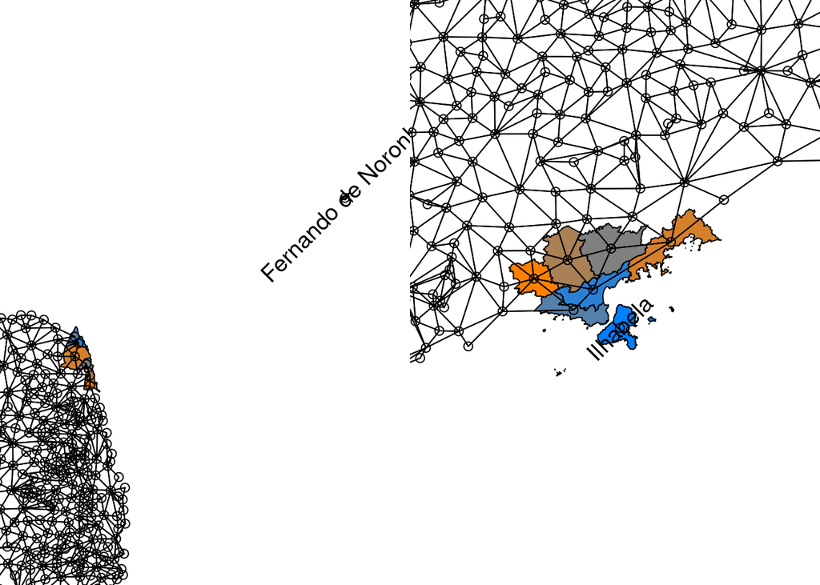

```r
par(mfrow=c(1,n0), mar=c(0,0,0,0))##, xaxs='i', yaxs='i')
for (i in 1:n0) {
    plot(map[ii0near[,i], ], col=rgb(0:6/6, 0.5, 6:0/6),
         xlim=bbox(map[ii0near[,i], ])[1, ] + c(-1, 1)/2)
    plot(nb0, coo, add=TRUE)
    text(coo[ii0[i], 1], coo[ii0[i], 2],
         map@data$NM_MUN[ii0[i]], cex=1.2, srt=45)
}
```

Adicionamos os dois municípios mais próximos como vizinhos desses 2 municípios sem vizinhos.

```r
nb <- nb0
for (i in 1:n0) {
    jj <- as.integer(ii0near[2:3, i])
    nb[[ii0[i]]] <- jj
    nb[[jj[1]]] <- c(nb[[jj[1]]], ii0[i])
    nb[[jj[2]]] <- c(nb[[jj[2]]], ii0[i])
}
nb0
```

```
## Neighbour list object:
## Number of regions: 5572
## Number of nonzero links: 32972
## Percentage nonzero weights: 0.1061996
## Average number of links: 5.917444
## 2 regions with no links:
## 1525 3499
```

```r
nb[ii0]
```

```
## [[1]]
## [1] 1158 1173
##
## [[2]]
## [1] 3388 3834
```

Visualizamos o resultado

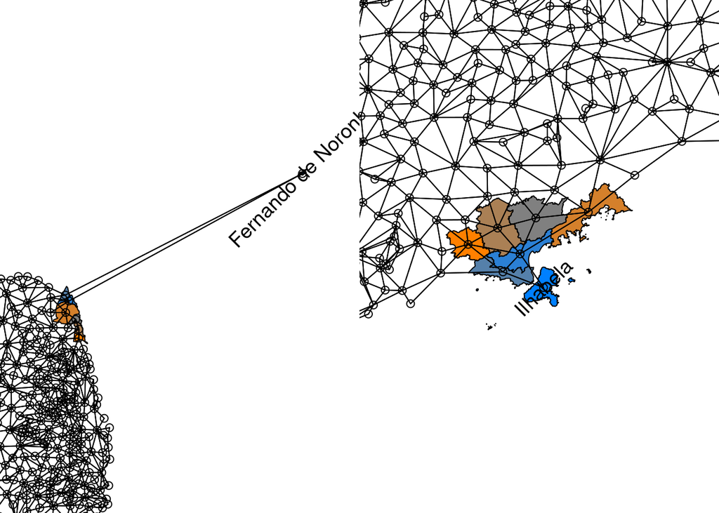

```r
par(mfrow=c(1,n0), mar=c(0,0,0,0))##, xaxs='i', yaxs='i')
for (i in 1:n0) {
    plot(map[ii0near[,i], ], col=rgb(0:6/6, 0.5, 6:0/6),
         xlim=bbox(map[ii0near[,i], ])[1, ] + c(-1, 1)/2)
    plot(nb, coo, add=TRUE)
    text(coo[ii0[i], 1], coo[ii0[i], 2],
         map@data$NM_MUN[ii0[i]], cex=1.2, srt=45)
}
```

É comum usar listas de vizinhanças em modelos estimados com o pacote *INLA*. Podemos usar a função `nb2INLA` para exportar a lista de vizinhança no formato de arquivo de vizinhança que o o *INLA* usa com

```r
nb2INLA('graph.txt', nb)
```

# Adicionando dados

É comum considerar dados de utilização, estatísticas vitais (nacimento ou óbito), notificações compulsórias ou dados de censos disponibilizados pelo DATASUS, DATASUS: (2017).

## Exemplo

Consideremos um exemplo que pode ser seguido para as outras variáveis que o DATASUS disponibiliza ao nível agregado por municípios. Suponha que consultamos algumas das variáveis disponíveis por municípios oriundas do Censo Demográfico Brasileiro e disponibilizadas pelo DATASUS a partir do link http://tabnet.datasus.gov.br/cgi/tabcgi.exe?ibge/cnv/sanbr.def, variáveis estas relativas às instalações sanitárias.

Como exemplo, vamos pedir para organizar o resultado com município nas linhas, “Instalações sanitárias” nas colunas e o conteúdo “Moradores”, e selecionar ano “2010”, como na figura a seguir

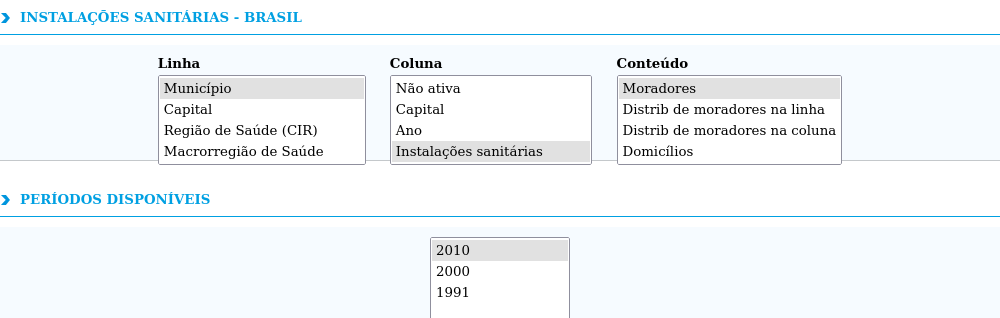

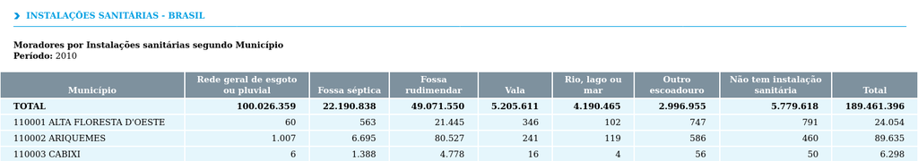

No final dessa tela há a opção de salvar essa tabela como um arquivo em formato CSV, clicando no botão “COPIA COMO CSV”, conforme mostrado na figura a seguir

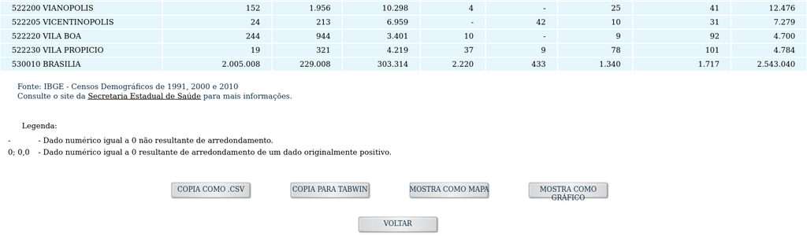

Clicando nesse botão, uma arquivo será salvo no seu computador. No exemplo, as primeiras linhas desse arquivo serão como na figura a seguir

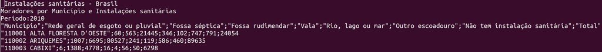

## Juntando dados ao mapa

Precisamos agora juntar os dados ao mapa. Ou, simplesmente, colocar os dados na ordem do mapa para possibilitar análises considerando a localização geográfica.

Vamos ler os dados supondo que o nome do arquivo seja “saneamento_moradores.csv” a seguir. É preciso utilizar `skip = 3` para ler a partir da linha 4 e utilizo `encoding = "latin1"` porque o sistema operacional que uso tem encoding padrão diferente.

```r
saneamento <- read.csv2(
  "saneamento_moradores.csv",
  skip = 3,
  na.strings = "-",
  encoding = "latin1")
head(saneamento,2)
```

```
##                      Município Rede.geral.de.esgoto.ou.pluvial Fossa.séptica
## 1 110001 ALTA FLORESTA D'OESTE                              60           563
## 2             110002 ARIQUEMES                            1007          6695
##   Fossa.rudimendar Vala Rio..lago.ou.mar Outro.escoadouro
## 1            21445  346              102              747
## 2            80527  241              119              586
##   Não.tem.instalação.sanitária Total
## 1                          791 24054
## 2                          460 89635
```

A primeira coluna dos dados contem um código de município, com 6 dígitos, e o nome do município concatenados. Portanto, vamos utilizar os 6 primeiros caracteres. O código de município no padrão do IBGE contem 7 dígitos, mas os 6 primeiros são suficientes para o nosso propósito.

```r
head(map@data,2)
```

```
##    CD_MUN                NM_MUN SIGLA_UF AREA_KM2
## 0 1100015 Alta Floresta D'Oeste       RO 7067.025
## 1 1100023             Ariquemes       RO 4426.571
```

Criamos uma variável `area` para indexar o mapa a seguir

```r
saneamento$area <- pmatch(
  substr(saneamento[,1], 1, 6),
  substr(map@data[,1], 1, 6))
head(saneamento, 2)
```

```
##                      Município Rede.geral.de.esgoto.ou.pluvial Fossa.séptica
## 1 110001 ALTA FLORESTA D'OESTE                              60           563
## 2             110002 ARIQUEMES                            1007          6695
##   Fossa.rudimendar Vala Rio..lago.ou.mar Outro.escoadouro
## 1            21445  346              102              747
## 2            80527  241              119              586
##   Não.tem.instalação.sanitária Total area
## 1                          791 24054    1
## 2                          460 89635    2
```

## Plotting data

Vamos criar uma variável dividindo o número de moradores vivendo em domicílios que “Não tem instalação sanitária” pelo número “Total” de moradores, em cada município.

```r
saneamento$propSem <- saneamento$"Não.tem.instalação.sanitária"/saneamento$"Total"
```

Agora, vamos visualizar o mapa considerando uma variável do conjunto de dados. Há várias formas de fazer isso. A mais simples é adicionar a variável presente nos dados ao elemento `data` do mapa e usar a função `spplot()`. Há um porém aqui. Pode ocorrer que nem todas as áreas do mapa tenham dados. Neste caso a coluna `area` criada terá valor NA.

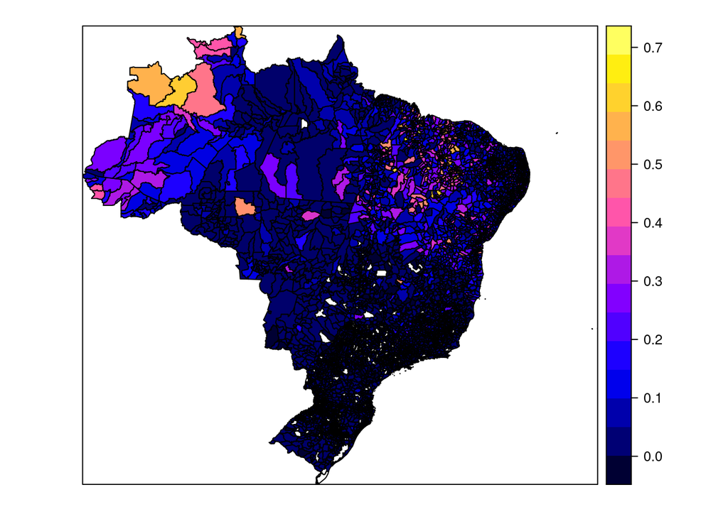

```r
map$semSaneamento <- rep(NA, nrow(map))
map$semSaneamento[(1:nrow(map)) %in% saneamento$area] <- saneamento$propSem[saneamento$area]
spplot(map, "semSaneamento")
```

# Referências

Besag, J., J. York, and A. Mollié. 1991. “Bayesian Image Restoration with Two Applications in Spatial Statistics (with Discussion).” *Aism* 43 (1): 1–59.

Bivand, Roger, Jan Hauke, and Tomasz Kossowski. 2013. “Computing the Jacobian in Gaussian Spatial Autoregressive Models: An Illustrated Comparison of Available Methods.” *Geographical Analysis* 45 (2): 150–79. http://www.jstatsoft.org/v63/i18/.

Bivand, Roger, and Gianfranco Piras. 2015. “Comparing Implementations of Estimation Methods for Spatial Econometrics.” *Journal of Statistical Software* 63 (18): 1–36. https://www.jstatsoft.org/v63/i18/.

DATASUS:, Departamento de Informatica do SUS. 2017. “Estatísticas Vitais.” http://datasus.saude.gov.br/informacoes-de-saude/tabnet/estatisticas-vitais.

Riebler, A., S. H. Søorbye, D. Simpson, and H. Rue. 2016. “An Intuitive Bayesian Spatial Model for Disease Mapping That Accounts for Scaling.” *Statistical Methods in Medical Research* 25 (4): 1145–65.

Sørbye, S. H., and H. Rue. 2014. “Scaling Intrinsic Gaussian Markov Random Field Priors in Spatial Modelling.” *Spatial Statistics* 8 (May): 39–51.